# Introduction

In this notebook, the goal is attempting to use ARMA models to predict the share of a company. ARMA models are used for time-series analysis, but may not be optimal to use for this case. However, this is more or less a demonstration of how such concepts can be applied in a real-life scenario. The shares prices for the company AMD (Advanced Micro Devices), from 14:20 to 15:48 on October 30, 2020. The data will be provided from Alpaca's API for market data. The data is by per-minute bars.

# Initialization

Start by importing the necessary libraries. In this case, the libraries that will be used are NumPy, Pandas, MatPlotLib StatsModels and Requests. Although Alpaca has it's own package for Python functionality, It would be more fair to be platform-neutral and do it the "old-fashioned" way. This part will cover the whole importing and processing data procedures. It will cover the library importing process, data importing process, data handling and processing procedures, and finally preparing the data for analysis.

### Libraries

Import the libraries with all of their features and components.

```python
import numpy as np
import pandas as pd
import requests as r
import matplotlib.pyplot as plt
import statsmodels.api as sm
```

### Data import & processing

Import the data from the API. Because this is a RESTful API, the fetched data will be in JSON format, which means that it would have to be converted into a pandas dataframe for it to become readable in Python. To read about the API, check out the documentation [here](https://alpaca.markets/docs/)

```python
### Data Import

url = 'https://data.alpaca.markets/v1/bars/1Min?symbols=AMD&start=2020-10-30T14:20:00.000Z&end=2020-10-30T15:48:00.000Z'
headers = {'APCA-API-KEY-ID': {API key}, 'APCA-API-SECRET-KEY': {API secret key}}
data = r.get(url, headers = headers)
##The above method fetches the GET response
data = data.json()
##This method parses the response JSON format
data = data['AMD']
##Turns out it's a nested JSON, this method
##Basically reads the values that are nested
data = pd.DataFrame(data)
##This method just converts the data from JSON
##to a Pandas dataframe
data.head()

## As you can see, the steps were basically using the Alpaca API with the API keys
## in an HTTP GET request to get the data in JSON format, then parsed the data
## in JSON format, only to realize that the problem with the data is that it was nested
## in an object, which means Python had to access the nested object to read the data. Only then
## It was possible to convert the data into a pandas dataframe.
```

|  | t | o | h | l | c | v |
| --- | --- | --- | --- | --- | --- | --- |
| 0 | 1604067600 | 75.450 | 75.450 | 75.390 | 75.430 | 5531 |
| 1 | 1604067660 | 75.410 | 75.510 | 75.400 | 75.480 | 6291 |
| 2 | 1604067720 | 75.480 | 75.485 | 75.395 | 75.430 | 4958 |
| 3 | 1604067780 | 75.455 | 75.570 | 75.410 | 75.540 | 6991 |
| 4 | 1604067840 | 75.530 | 75.560 | 75.360 | 75.361 | 4835 |

As it can be seen, the data is now in a readable tabular format. See what the column names mean [here](https://alpaca.markets/docs/api-documentation/api-v2/market-data/bars/). In this case, the 'o' column, which represents the opening price at this point, and the 't' column, which represents the time, are the data points that will be used for the analysis. The opening price in this case would be better than the closing price because it would essentially convert the data from a "per minute" basis into an instantaneous point in time, which is preferable in this case for simplicity purposes.

```python
data = data[['t', 'o']]
data = data.rename(columns={'t': "datetime", 'o': 'price'})
data.head()
```

|  | datetime | price |
| --- | --- | --- |
| 0 | 1604067600 | 75.450 |
| 1 | 1604067660 | 75.410 |
| 2 | 1604067720 | 75.480 |
| 3 | 1604067780 | 75.455 |
| 4 | 1604067840 | 75.530 |

The data is now labeled better, making it easier to understand. Now, the time column is in UNIX Epoch time. This can be done with Pandas by doing the following:

```python
data['datetime'] = pd.to_datetime(data['datetime'], unit='s')
data.head()
```

|  | datetime | price |
| --- | --- | --- |
| 0 | 2020-10-30 14:20:00 | 75.450 |
| 1 | 2020-10-30 14:21:00 | 75.410 |
| 2 | 2020-10-30 14:22:00 | 75.480 |
| 3 | 2020-10-30 14:23:00 | 75.455 |
| 4 | 2020-10-30 14:24:00 | 75.530 |

Now that it has been processed well enough for analysis, the next step will be viewing the data and and seeing what can be done with this dataset.

# Starting Analysis

View the data and explore any patterns or conditions. This can be done with matplotlib.

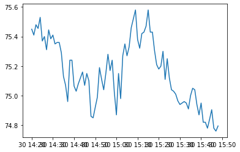

```python
amd = plt.plot(data['datetime'], data['price'])
```

What's clear in this dataset is that it violates almost all conditions required to run an ARMA model, so what can be done is try to convert it into a stationary process using several transformations. To start, try to normalize the dataset by converting the values into standardized z scores. This is simple but should be very effective.

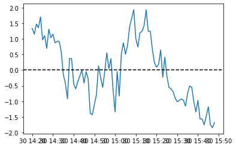

```python
mu = np.mean(data['price'])
sigma = np.std(data['price'])

data['data_norm'] = (data['price'] - mu) / sigma
plt.plot( data['datetime'], data['data_norm'])
plt.axhline(0, color = 'black', linestyle = '--')
```

|  | datetime | price | data_norm | diff |
| --- | --- | --- | --- | --- |
| 0 | 2020-10-30 14:20:00 | 75.450 | 1.334436 | NaN |
| 1 | 2020-10-30 14:21:00 | 75.410 | 1.150169 | -0.184267 |
| 2 | 2020-10-30 14:22:00 | 75.480 | 1.472637 | 0.322468 |
| 3 | 2020-10-30 14:23:00 | 75.455 | 1.357470 | -0.115167 |
| 4 | 2020-10-30 14:24:00 | 75.530 | 1.702971 | 0.345501 |

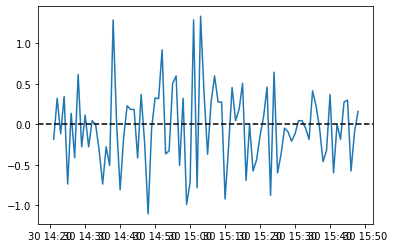

```python
data['diff'] = data['data_norm'].diff().dropna(inplace=False)
plt.plot(data['datetime'], data['diff'])
plt.axhline(0, color = 'black', linestyle = '--')
data.head()
```

The data now seems to have a much better pattern than before. Check for stationarity using The Augmented Dickey-Fuller Unit-Root Test. Looking at the [statsmodels ADF documentation](https://www.statsmodels.org/dev/generated/statsmodels.tsa.stattools.adfuller.html), the $1^{st}$ value of the array is the ADF value, and the $2^{nd}$ value is the p-value. If the p-value is below 0.05, it means that value is significant enough to assume that the data is stationary. The returning output is not the most user-friendly, so creating a function to better organize the output for relevant information here is a good idea.

```python
def adf_test(arr):

    res = sm.tsa.stattools.adfuller(arr.dropna())
    print('ADF value is: ', res[0])
    print('p-value is: ', float(res[1]))

adf_test(data['diff'])
```

```
ADF value is:  -6.499321237601667
p-value is:  1.1725812698295796e-08
```

The value is much lower than 0.05, which makes it very safe to assume that the data is now stationary. Now, viewing a PACF plot would be good to determine the number of lags.

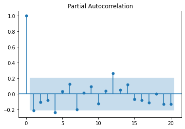

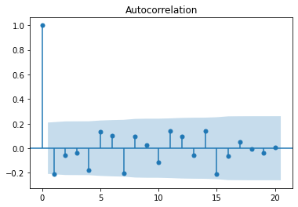

```python
sm.graphics.tsa.plot_pacf(data['diff'].dropna())
sm.graphics.tsa.plot_acf(data['diff'].dropna())
plt.show()
```

Given the PACF and ACF, it is apparent that for the most accurate results, the model should only predict up to 1 lag at most. The next step will be building the model, fitting it, plotting it, and compare it to the actual results.

# Building An ARMA Model

The model will be built using the statsmodels ARIMA features. This is straight-forward and can be done by:

```python
model = sm.tsa.arima.ARIMA(data['diff'], order = (1, 0, 1))
```

Basically, this generates an ARMA model because the second order value is the difference, which is 0 in this case because the model should be an ARMA model. The 1's are the order of MA and AR. The MA and AR were chosen to be of the $1^{st}$ order for the best results. Now, fit the model and forecast the results by:

```python
model_fit = model.fit()
model_fit.forecast(1)
```

```
89   -0.043091
dtype: float64
```

$\hat{Y}_{n} = \sigma*(\hat{v_{n}} + norm_{n-1}) + \mu $

Where $\hat{Y}_{n}$ is the predicted price, $\hat{v_{n}}$ is the forecasted normalized difference (the value the model forecasts), and $norm_{n-1}$ is the normalized value of the previous (lagging) data point. Writing a function to obtain the price given this equation would be a good step to take here.

```python
def price_pred(val):
    res = sigma * (val + data['data_norm'][len(data)-1]) + mu
    return res

price_pred(-0.043091)
```

```
74.78564597534005
```

This is the final output. It is the price that the fitted model forecasts given the data. This function could also be easily scaled if it should predicted more lags.

# Summary

In total, this document went through obtaining data from external sources, processing and preparing it, then transforming it and running diagnostics, then finally fitting a model and forecasting the results. Of course, this model has it's limitations. For example, it doesn't account for other market external factors. But overall, the whole notebook closely mimics the process of obtaining data and attemping gather valuable information. The notebook offers great insight on what it's like handling real world data and how to shift data into something more usable.